# Homework #3: Computational Questions

All computations should be done in this notebook using the R kernel. Working in small groups is allowed, but it is important that you make an effort to master the material and hand in your own work.

#### You will be required to submit this notebook, fully compiled with your solutions, as an HTML or ipynb file to Canvas by 2pm on Friday, Feburary 9.

## Problem 1

There is an urn that has 100 marbles in it: 2 are red, 70 are yellow, 13 are green and 15 are blue. Simulate data to imitate someone drawing a marble from the urn (replacing after each draw), with the color recorded at each draw (HINT: the ${\tt sample()}$ function in ${\tt R}$ will be useful here).

#### (a) Plot the fraction of times a yellow marble is drawn in the first 1000 draws. On the x-axis, include the number of draws, and on the y-axis, include the cumulative fraction of yellow draws. Why does this number fluctuate more when the number of draws is smaller?

'The number of yellow draws fluctuates when the number of draws is smaller because the actual draws only approach \nthe probabilities over a large number of draws.'

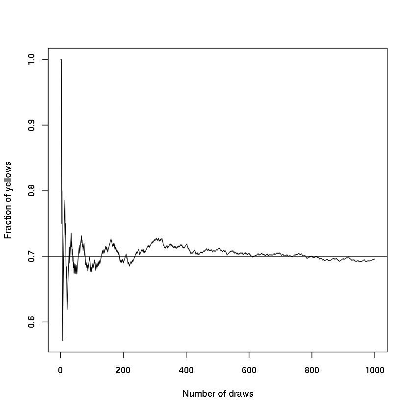

```r
set.seed(1)

x = c('red', 'yellow', 'green', 'blue')
urn = sample(x, size = 1000, replace = TRUE, prob = c(0.02, 0.70, 0.13, 0.15))

yellows = matrix(nrow = 1000, ncol = 1)

for (i in c(1:1000)) {
    current = urn[1:i]
    yellows[i] = length(current[current == "yellow"])/i
}

plot(yellows, type="l", xlab="Number of draws", ylab="Fraction of yellows")
abline(h = 0.70)

"The number of yellow draws fluctuates when the number of draws is smaller because the actual draws only approach
the probabilities over a large number of draws."
```

#### (b) How many draws are needed before the fraction of yellow marbles drawn in the simulated data is close to the probability of drawing a yellow marble?

```r
"Around 600 draws"
```

'Around 600 draws'

#### (c) Repeat the two steps above for the red marble. What do you notice that is different, and why do you think it is different?

'The fraction of reds stabalize on the true probability around draw 800. \nIt takes much longer because reds are much more uncommon.'

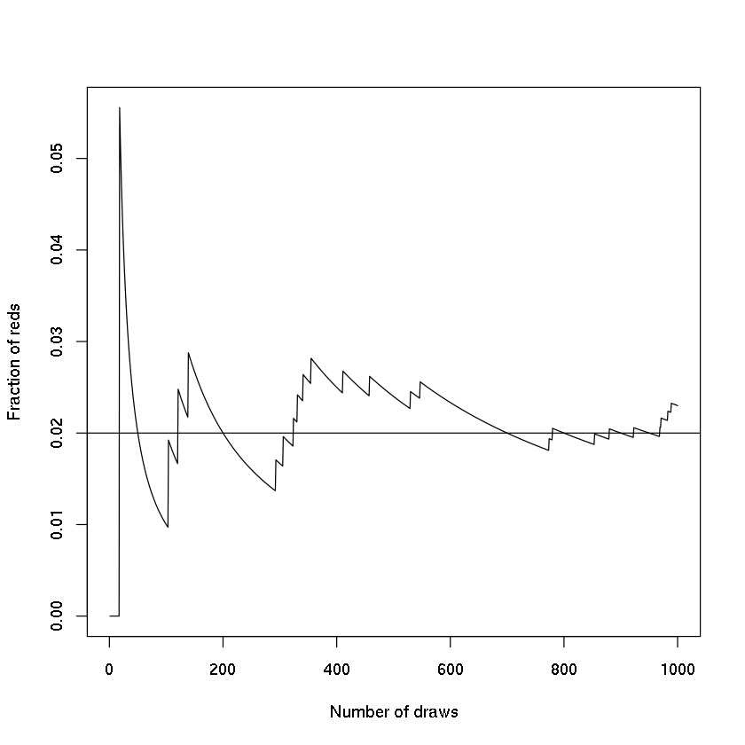

```r
reds = matrix(nrow = 1000, ncol = 1)

for (i in c(1:1000)) {
    current = urn[1:i]
    reds[i] = length(current[current == "red"])/i
}

plot(reds, type="l", xlab="Number of draws", ylab="Fraction of reds")
abline(h = 0.02)

"The fraction of reds stabalize on the true probability around draw 800.
It takes much longer because reds are much more uncommon."
```

## Problem 2

#### (a) Run a simulation that estimates the probability calculation in theoretical question 1 (b). That is, simulate the birthdays (you can use the numbers 1 through 365) of 45 people many many times, and find the relative frequency of cases in which at least two people share a birthday (HINT: The ${\tt sample()}$ and ${\tt replicate()}$ functions in ${\tt R}$ will be useful here).

```r
set.seed(1)
counts = matrix(ncol = 1, nrow = 1000)
total = 0
n = 2000

for (k in c(1:n)) {
    birthdays = sample(c(1:365), size = 45, replace = TRUE)
    count = 0

    for (i in c(1:45)) {
        for (j in c(1:45)) {
            if (birthdays[j] == birthdays[i] && i != j) {
                count = count + 1;
            }
        }
    }

    counts[k] = count / 2
    total = total + (count / 2)
}

"Average shared birthdays:"
total / n

"Probability of two or more people sharing a birthday with 45 people:"
total / n / 45

"6% probability of having the same birthday as someone else in the room"
```

'Average shared birthdays:'

2.692

'Probability of two or more people sharing a birthday with 45 people:'

0.0598222222222222

'6% probability of having the same birthday as someone else in the room'

#### (b) Run a simulation that estimates the probability calculation in theoretical question 1 (c).

'11% probability that the sum of three rolls equals 12'

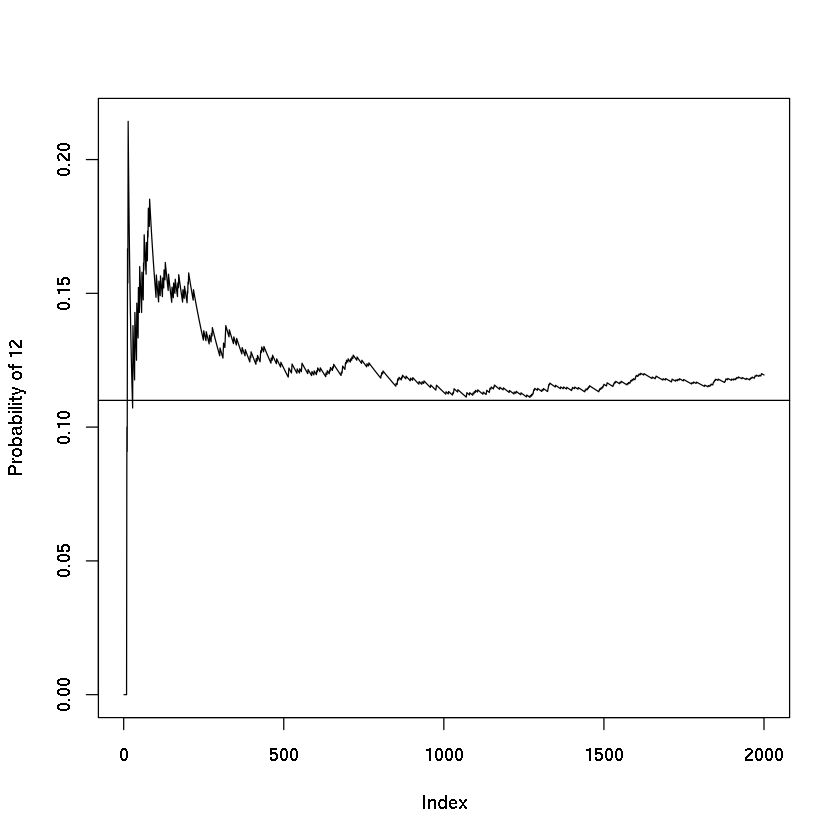

'10% probability that the sum of three rolls equals 13'

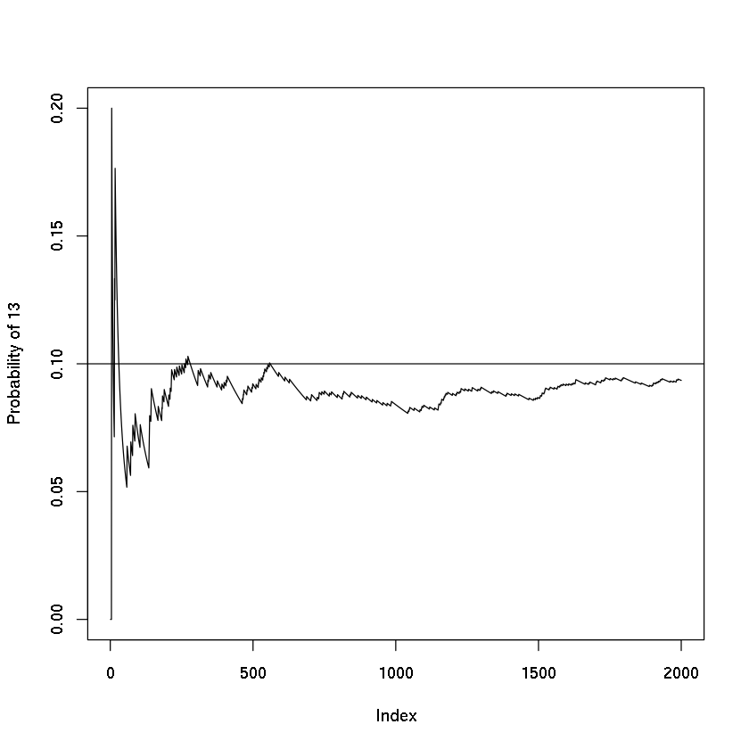

```r
set.seed(1)
rolls = replicate(2000, sample(c(1:6), 3, replace = TRUE))
totals = matrix(ncol = 1, nrow = 2000)
prob12 = matrix(ncol = 1, nrow = 2000)
prob13 = matrix(ncol = 1, nrow = 2000)

for (i in c(1:2000)) {
    totals[i] = rolls[1, i] + rolls[2, i] + rolls[3, i]
    temp = totals[1:i]
    prob12[i] = length(temp[temp == 12]) / i
    prob13[i] = length(temp[temp == 13]) / i
}

plot(prob12, type = "l", ylab = "Probability of 12")
abline(h = 0.11)

"11% probability that the sum of three rolls equals 12"

plot(prob13, type = "l", ylab = "Probability of 13")
abline(h = 0.1)

"10% probability that the sum of three rolls equals 13"
```

#### (c) Run a simulation that estimates the probability calculation in theoretical question 4 (a).

'6/6 * 1/6 * 1/6 * 1/6 * 1/6 = 0.0007716 = 154321/200000000 = Probability of Yahtzee from Computational HW'

'Probability of a Yahtzee on the first round:'

0.000675

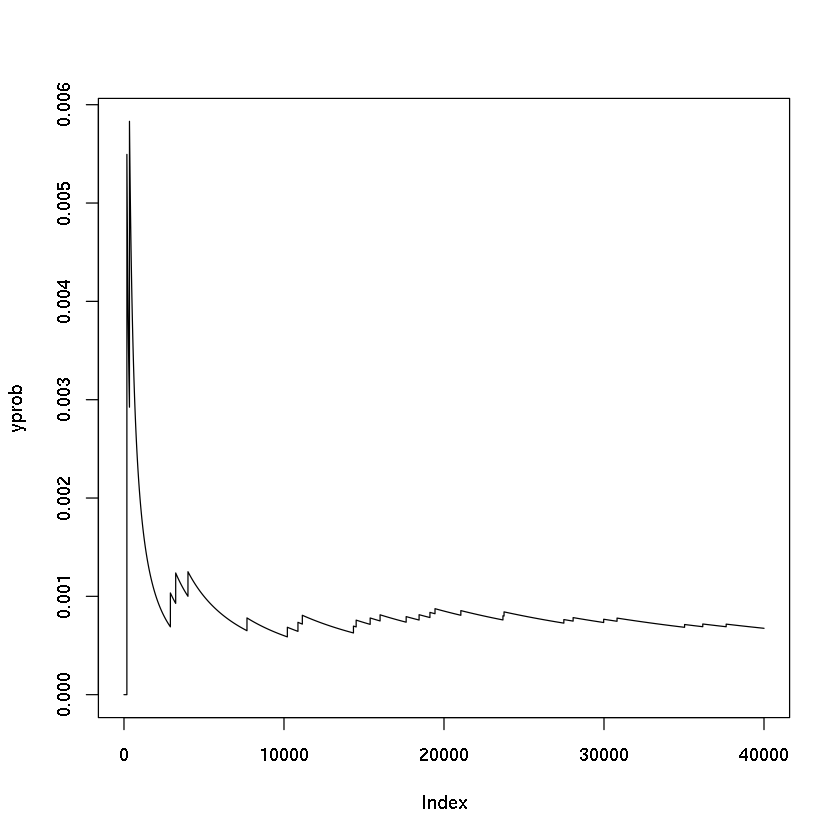

```r
"6/6 * 1/6 * 1/6 * 1/6 * 1/6 = 0.0007716 = 154321/200000000 = Probability of Yahtzee from Computational HW"

set.seed(1)
rolls = replicate(40000, sample(c(1:6), 5, replace = TRUE))
yahtzees = matrix(ncol = 1, nrow = 40000)
yprob = matrix(ncol = 1, nrow = 40000)


for (i in c(1:40000)) {
    if (rolls[1, i] == rolls[2, i] && rolls[1, i] == rolls[3, i] && rolls[1, i] == rolls[4, i] && rolls[1, i] == rolls[5, i]) {
        yahtzees[i] = 1
    } else {
        yahtzees[i] = 0
    }
    ytemp = yahtzees[1:i]
    yprob[i] = length(ytemp[ytemp == 1]) / i
}

plot(yprob, type = "l")

"Probability of a Yahtzee on the first round:"
length(yahtzees[yahtzees == 1]) / 40000
```